# Econometria espacial com R - Aula 05

Unicamp, julho de 2018

Raphael Saldanha, Eduardo Almeida

# Probit e Tobit espacial

## Pacotes

```r
library(McSpatial)
```

## Shapefile

```r
# Pacotes
library(rgdal)
lula.shp <- readOGR("data", "lula2002", encoding = "ISO-8859-1")
```

## Variável de resposta

Para estes tipos de modelo, precisamos ter ou criar uma variável dicotômica para ser a variável de resposta do modelo.

```r
lula.shp@data$VITORIA <- lula.shp@data$PT > lula.shp@data$PPS & lula.shp@data$PSB & lula.shp@data$ PSDB
table(lula.shp@data$VITORIA)
```

```
FALSE  TRUE
  358  5149
```

## Matriz de vizinhança

Para usar o pacote `McSpatial`, a matriz de vizinhança precisa ser criada através de um comando do próprio pacote, não podendo ser usada diretamente as matrizes que criamos com o pacote `spdep`. Abaixo, alguns exemplos de matrizes com este pacote. Vamos usar a última nos exemplos.

```r
# Matriz de pesos espaciais tipo "Queen"
wmat <- makew(lula.shp)$wmat
# Matriz de pesos espaciais tipo "Rook"
wmat <- makew(lula.shp, method="rook")$wmat
# Matriz de pesos espaciais tipo k-vizinhos
wmat <- makew(lula.shp, method="knear", knum=1)$wmat
```

## Especificação

```r
esp <- VITORIA ~ F1N + F2N + F3N + F4N
```

## Logit espacial

```r
fit1 <- splogit(form = esp, data = lula.shp@data, wmat = wmat)
```

```
Call:
glm(formula = form, family = binomial(link = "logit"), data = data)

Deviance Residuals:
     Min        1Q    Median        3Q       Max
-2.93267   0.08999   0.16209   0.37299   1.57369

Coefficients:
            Estimate Std. Error z value Pr(>|z|)
(Intercept)  -2.3403     0.3012  -7.769 7.90e-15 ***
F1N          10.4619     0.5675  18.436  < 2e-16 ***
F2N           3.1929     6.3813   0.500  0.61683
F3N           2.2868     0.8369   2.733  0.00629 **
F4N           2.9712     0.4366   6.805 1.01e-11 ***
---
Signif. codes:  0 ‘***’ 0.001 ‘**’ 0.01 ‘*’ 0.05 ‘.’ 0.1 ‘ ’ 1

(Dispersion parameter for binomial family taken to be 1)

    Null deviance: 2649.2  on 5506  degrees of freedom
Residual deviance: 2017.9  on 5502  degrees of freedom
AIC: 2027.9

Number of Fisher Scoring iterations: 8

STANDARD LOGIT ESTIMATES
LINEARIZED GMM LOGIT ESTIMATES
            Estimate Std. Error  z-value Pr(>|z|)
(Intercept) -2.48384    0.34628 -7.17286  0.00000
F1N          9.22088    0.55403 16.64317  0.00000
F2N          3.44637   10.64316  0.32381  0.74608
F3N          1.74773    0.61619  2.83636  0.00456
F4N          3.02821    0.39190  7.72692  0.00000
WXB          0.21576    0.04304  5.01282  0.00000
Number of observations =  5507
```

A especificação dos instrumentos envolve, por default, tanto $X$ quanto $WX$ . Para mudar esta especificação, você pode listar quais variáveis devem ser ponderadas pela matriz de pesos espaciais com o argumento `winst`, quais variáveis não devem ser ponderadas com o argumento `inst`, ou usando ambos os argumentos. Saiba mais sobre os efeitos destas combinações com `?splogit`, em Details.

## Probit espacial

### Estimado por GMM

```r
fit2 <- spprobit(form = esp, data = lula.shp@data, wmat = wmat)
```

```
Call:
glm(formula = form, family = binomial(link = "probit"), data = data)

Deviance Residuals:
     Min        1Q    Median        3Q       Max
-3.05165   0.05328   0.13326   0.38482   1.45241

Coefficients:
            Estimate Std. Error z value Pr(>|z|)
(Intercept)  -1.1556     0.1511  -7.645 2.08e-14 ***
F1N           5.5295     0.2923  18.915  < 2e-16 ***
F2N           1.4137     2.2864   0.618  0.53638
F3N           1.3159     0.4163   3.161  0.00157 **
F4N           1.5268     0.2272   6.721 1.80e-11 ***
---
Signif. codes:  0 ‘***’ 0.001 ‘**’ 0.01 ‘*’ 0.05 ‘.’ 0.1 ‘ ’ 1

(Dispersion parameter for binomial family taken to be 1)

    Null deviance: 2649.2  on 5506  degrees of freedom
Residual deviance: 1988.1  on 5502  degrees of freedom
AIC: 1998.1

Number of Fisher Scoring iterations: 8

STANDARD PROBIT ESTIMATES
LINEARIZED GMM PROBIT ESTIMATES
            Estimate Std. Error   z-value Pr(>|z|)
(Intercept) -1.25933    0.10908 -11.54552   0.0000
F1N          4.85698    0.23126  21.00256   0.0000
F2N          1.64951    0.72345   2.28005   0.0226
F3N          1.08684    0.22738   4.77982   0.0000
F4N          1.58326    0.15459  10.24194   0.0000
WXB          0.21644    0.03179   6.80787   0.0000
Number of observations =  5507
```

### Estimado por ML

Rodar em casa com tempo ;-)

```r
fit3 <- spprobitml(form = esp, data = lula.shp@data, wmat = wmat)
```

```
Standard Probit Estimates

Call:
glm(formula = form, family = binomial(link = "probit"), data = data)

Deviance Residuals:
     Min        1Q    Median        3Q       Max
-3.05165   0.05328   0.13326   0.38482   1.45241

Coefficients:
            Estimate Std. Error z value Pr(>|z|)
(Intercept)  -1.1556     0.1511  -7.645 2.08e-14 ***
F1N           5.5295     0.2923  18.915  < 2e-16 ***
F2N           1.4137     2.2864   0.618  0.53638
F3N           1.3159     0.4163   3.161  0.00157 **
F4N           1.5268     0.2272   6.721 1.80e-11 ***
---
Signif. codes:  0 ‘***’ 0.001 ‘**’ 0.01 ‘*’ 0.05 ‘.’ 0.1 ‘ ’ 1

(Dispersion parameter for binomial family taken to be 1)

    Null deviance: 2649.2  on 5506  degrees of freedom
Residual deviance: 1988.1  on 5502  degrees of freedom
AIC: 1998.1

Number of Fisher Scoring iterations: 8

Conditional on rho
rho =  0.2483219
         Estimate Std. Error    z-value     Pr(>|z|)
VITORIA -1.188460  0.1423065 -8.3514121 0.000000e+00
F1N      4.996325  0.2690747 18.5685397 0.000000e+00
F2N      1.237156  2.3078522  0.5360637 5.919145e-01
F3N      1.100396  0.3753069  2.9319894 3.367983e-03
F4N      1.361295  0.2173777  6.2623485 3.792222e-10
Unconditional Standard Errors
          Estimate Std. Error    z-value     Pr(>|z|)
VITORIA -1.1884602 0.25282116 -4.7007942 2.591516e-06
F1N      4.9963251 0.44425006 11.2466504 0.000000e+00
F2N      1.2371558 7.93365211  0.1559377 8.760821e-01
F3N      1.1003958 0.60557561  1.8171073 6.920069e-02
F4N      1.3612952 0.27192094  5.0062169 5.551022e-07
rho      0.2483219 0.05051368  4.9159339 8.836021e-07
Number of observations =  5507
```

# Painel espacial

Para iniciarmos nossos painéis espaciais, pode ser interessante abrir espaço na memória do computador. Para apagar todos os objetos, use o comando abaixo.

## Limpando a memória

```r
rm(list = ls())
```

## Pacotes

O pacote `plm` é responsável pelos painéis convencionais (não espaciais) que usaremos para comparação. O pacote `splm` é responsável pelos painéis espaciais. Os autores do pacote lançaram um artigo sobre ele neste [link](https://www.jstatsoft.org/article/view/v047i01/v47i01.pdf).

```r
library(plm)
library(splm)
```

## Shapefile

Vamos usar um shapefile de estados brasileiros com dados sobre criminalidade.

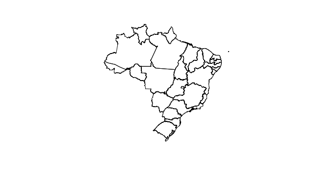

```r
# Pacotes
library(rgdal)
crime.shp <- readOGR("data", "Crime_UF3", encoding = "ISO-8859-1")
# Plotar o mapa
plot(crime.shp)
```

## Dados

Uma olhada nos dados.

```r
str(crime.shp@data)
```

```
'data.frame':   27 obs. of  27 variables:
 $ NAME2_  : Factor w/ 27 levels "ACRE","ALAGOAS",..: 1 2 3 4 5 6 7 8 9 10 ...
 $ UF_CODE : Factor w/ 27 levels "11","12","13",..: 2 14 6 3 16 10 27 18 26 8 ...
 $ UF      : Factor w/ 27 levels "Acre","Alagoas",..: 1 2 3 4 5 6 7 8 9 10 ...
 $ IGINI91 : num  0.623 0.625 0.582 0.623 0.664 0.654 0.614 0.598 0.585 0.599 ...
 $ IGINI00 : num  0.648 0.691 0.637 0.683 0.669 0.675 0.64 0.608 0.611 0.659 ...
 $ IDHMR91 : num  0.603 0.556 0.649 0.64 0.572 0.563 0.801 0.653 0.667 0.505 ...
 $ IDHMR00 : num  0.64 0.598 0.666 0.634 0.62 0.616 0.842 0.719 0.717 0.558 ...
 $ IDHNM91 : num  0.624 0.548 0.691 0.664 0.59 0.593 0.799 0.69 0.7 0.543 ...
 $ IDHNM00 : num  0.697 0.649 0.753 0.713 0.688 0.7 0.844 0.765 0.776 0.636 ...
 $ TURB91  : num  0.619 0.589 0.809 0.714 0.591 0.654 0.947 0.74 0.808 0.4 ...
 $ TURB00  : num  0.664 0.68 0.89 0.749 0.671 0.715 0.956 0.795 0.879 0.595 ...
 $ RPC91   : num  145 109 191 180 120 ...
 $ RPC00   : num  181 140 211 174 160 ...
 $ FVT99   : num  68.6 171.1 0 342.2 454.6 ...
 $ FVT00   : num  196.2 80.1 0 245 433.9 ...
 $ W_FVT99 : num  506 338 215 432 280 ...
 $ W_FVT00 : num  398 330 316 334 248 ...
 $ W_GINI99: num  0.618 0.648 0.619 0.62 0.621 ...
 $ W_GINI00: num  0.648 0.667 0.655 0.634 0.647 ...
 $ W_IDHR99: num  0.631 0.584 0.599 0.636 0.601 ...
 $ W_IDHR00: num  0.658 0.629 0.629 0.67 0.654 ...
 $ W_IDH99 : num  0.662 0.602 0.65 0.662 0.629 ...
 $ W_IDH00 : num  0.724 0.692 0.723 0.735 0.715 ...
 $ W_TURB99: num  0.648 0.657 0.525 0.621 0.672 ...
 $ W_TURB00: num  0.695 0.717 0.665 0.705 0.753 ...
 $ W_RPC99 : num  171 130 142 181 149 ...
 $ W_RPC00 : num  204 169 169 221 205 ...
```

```r
head(crime.shp@data)
```

|  | NAME2_ | UF_CODE | UF | IGINI91 | IGINI00 | IDHMR91 | IDHMR00 | IDHNM91 | IDHNM00 | TURB91 | TURB00 | RPC91 | RPC00 | FVT99 | FVT00 | W_FVT99 | W_FVT00 | W_GINI99 | W_GINI00 | W_IDHR99 | W_IDHR00 | W_IDH99 | W_IDH00 | W_TURB99 | W_TURB00 | W_RPC99 | W_RPC00 |
| --- | --- | --- | --- | --- | --- | --- | --- | --- | --- | --- | --- | --- | --- | --- | --- | --- | --- | --- | --- | --- | --- | --- | --- | --- | --- | --- | --- |
| 0 | ACRE | 12 | Acre | 0.623 | 0.648 | 0.603 | 0.640 | 0.624 | 0.697 | 0.619 | 0.664 | 144.73 | 180.70 | 68.56 | 196.21 | 506.4300 | 398.3250 | 0.617500 | 0.648500 | 0.631000 | 0.658500 | 0.662000 | 0.724000 | 0.648000 | 0.695000 | 170.9150 | 203.8800 |
| 1 | ALAGOAS | 27 | Alagoas | 0.625 | 0.691 | 0.556 | 0.598 | 0.548 | 0.649 | 0.589 | 0.680 | 109.13 | 139.91 | 171.13 | 80.13 | 337.8333 | 330.0200 | 0.648333 | 0.666667 | 0.584333 | 0.629000 | 0.602333 | 0.691667 | 0.657333 | 0.716667 | 129.5167 | 169.1500 |
| 2 | AMAPA | 16 | Amap | 0.582 | 0.637 | 0.649 | 0.666 | 0.691 | 0.753 | 0.809 | 0.890 | 190.59 | 211.39 | 0.00 | 0.00 | 214.8700 | 315.5000 | 0.619000 | 0.655000 | 0.599000 | 0.629000 | 0.650000 | 0.723000 | 0.525000 | 0.665000 | 141.5200 | 168.5900 |
| 3 | AMAZONAS | 13 | Amazonas | 0.623 | 0.683 | 0.640 | 0.634 | 0.664 | 0.713 | 0.714 | 0.749 | 180.09 | 173.92 | 342.25 | 244.96 | 431.7820 | 334.1840 | 0.619800 | 0.633800 | 0.636200 | 0.670400 | 0.662200 | 0.734800 | 0.621200 | 0.705000 | 181.0200 | 220.7360 |
| 4 | BAHIA | 29 | Bahia | 0.664 | 0.669 | 0.572 | 0.620 | 0.590 | 0.688 | 0.591 | 0.671 | 119.71 | 160.19 | 454.65 | 433.89 | 280.0213 | 248.0637 | 0.620750 | 0.647375 | 0.600875 | 0.653625 | 0.628625 | 0.714500 | 0.671625 | 0.753125 | 148.9112 | 205.1125 |
| 5 | CEARA | 23 | Cear | 0.654 | 0.675 | 0.563 | 0.616 | 0.593 | 0.700 | 0.654 | 0.715 | 113.86 | 156.24 | 117.66 | 176.21 | 284.6900 | 258.1550 | 0.638000 | 0.659250 | 0.559750 | 0.618000 | 0.587750 | 0.681750 | 0.642500 | 0.709500 | 113.6650 | 159.8025 |

Veja que ele já tem algumas variáveis defasadas espacialmente.

## Matriz de vizinhança

Para rodar os paineis espaciais, vamos precisar de uma matriz de vizinhança.

```r
w1 <- nb2listw(poly2nb(crime.shp, queen = TRUE))
summary(w1)
```

```
Characteristics of weights list object:
Neighbour list object:
Number of regions: 27
Number of nonzero links: 102
Percentage nonzero weights: 13.99177
Average number of links: 3.777778
Link number distribution:

1 2 3 4 5 6 7 8
2 6 7 2 4 4 1 1
2 least connected regions:
2 20 with 1 link
1 most connected region:
4 with 8 links

Weights style: W
Weights constants summary:
   n  nn S0       S1       S2
W 27 729 27 16.95143 115.6406
```

## Variáveis defasadas espacialmente

Caso queira criar outras variáveis defasadas espacialmente, use o seguinte comando.

```r
crime.shp@data$lag_IDHMR91 <- lag.listw(w1, crime.shp@data$IDHMR91)
```

## Empilhar dados

Para empilhar os dados de modo automático, vamos precisar que a base de dados tenha uma organização básica.

- O primeiro campo deve ser o de identificação;
- Os nomes das variáveis devem conter a especificação da variável e o ano, algo como “PIB2000” e “PIB2010”.
- Não devem existir outras variáveis além da identificação e dados do painel.

Vejamos a base de dados do exemplo.

```r
dados <- crime.shp@data
names(dados)
```

```
 [1] "NAME2_"      "UF_CODE"     "UF"          "IGINI91"     "IGINI00"
 [6] "IDHMR91"     "IDHMR00"     "IDHNM91"     "IDHNM00"     "TURB91"
[11] "TURB00"      "RPC91"       "RPC00"       "FVT99"       "FVT00"
[16] "W_FVT99"     "W_FVT00"     "W_GINI99"    "W_GINI00"    "W_IDHR99"
[21] "W_IDHR00"    "W_IDH99"     "W_IDH00"     "W_TURB99"    "W_TURB00"
[26] "W_RPC99"     "W_RPC00"     "lag_IDHMR91"
```

Primeiro, vamos retirar as variáveis que não precisamos, como as de nome da UF.

```r
dados$NAME2_ <- NULL
dados$UF <- NULL
```

Vamos organizar os nomes das variáveis. Neste exemplo, entendi que 99 irá percenter no painel como se fosse 1991.

```r
names(dados) <- c("coduf", "IGINI91", "IGINI00", "IDHMR91", "IDHMR00", "IDHNM91", "IDHNM00", "TURB91", "TURB00", "RPC91", "RPC00", "FVT91", "FVT00", "W_FVT91", "W_FVT00", "W_GINI91", "W_GINI00", "W_IDHR91", "W_IDHR00", "W_IDH91", "W_IDH00", "W_TURB91", "W_TURB00","W_RPC91", "W_RPC00")
```

Para colocar os dados em painel, criamos uma função. Veja abaixo.

```r
painel <- function(id, dados){
  require(reshape2)

  dadosp <- reshape2::melt(dados, id=id)
  dadosp$varname <- as.character(gsub("[[:digit:]]", "", dadosp$variable))
  dadosp$year <-  as.character(gsub("[[:alpha:]]", "", dadosp$variable))

  sp <- split(dadosp, f = dadosp$varname)

  dadosp <- data.frame(sp[[1]][,1], sp[[1]]$year)

  for(i in 1:length(sp)){
    dadosp <- cbind(dadosp, sp[[i]]$value)
  }

  names(dadosp) <- c("id","ano",names(sp))

  return(dadosp)
}
```

Depois de declarada, vamos colocar os dados em painel.

```r
dadosp <- painel("coduf", dados)
View(dadosp)
```

## Especificação do modelo

```r
esp <- FVT ~ IDHMR + IGINI + RPC + TURB
```

## Modelo não espacial de efeitos fixos

```r
fe <- plm(esp, data=dadosp)
```

## Modelo não espacial de efeitos aleatórios

```r
re <- plm(esp, data=dadosp, model="random")
```

## Teste de Hausman

```r
ph <- phtest(fe, re) # H0: efeitos aleatórios
print(ph)
```

```
    Hausman Test

data:  esp
chisq = 25.503, df = 4, p-value = 3.985e-05
alternative hypothesis: one model is inconsistent
```

## Teste Pesaran CD (cross-section dependence)

```r
cd <- pcdtest(esp, data=dadosp) # H0: ausência de dependência CS
```

```
Insufficient number of observations in time to estimate heterogeneous model: using within residuals
```

```r
print(cd)
```

```
    Pesaran CD test for cross-sectional dependence in panels

data:  FVT ~ IDHMR + IGINI + RPC + TURB
z = -0.67937, p-value = 0.4969
alternative hypothesis: cross-sectional dependence
```

## Modelo OLS

```r
modOLS <- plm(esp, data=dadosp)
summary(modOLS)
```

```
Oneway (individual) effect Within Model

Call:
plm(formula = esp, data = dadosp)

Balanced Panel: n = 27, T = 2, N = 54

Residuals:
       Min.     1st Qu.      Median     3rd Qu.        Max.
-1.5698e+02 -3.9605e+01 -1.5588e-13  3.9605e+01  1.5698e+02

Coefficients:
        Estimate Std. Error t-value Pr(>|t|)
IDHMR  3117.0580  1844.8603  1.6896  0.10462
IGINI  1523.1320  1183.7552  1.2867  0.21100
RPC      -1.2625     1.0501 -1.2023  0.24149
TURB  -2129.3507   606.2171 -3.5125  0.00187 **
---
Signif. codes:  0 ‘***’ 0.001 ‘**’ 0.01 ‘*’ 0.05 ‘.’ 0.1 ‘ ’ 1

Total Sum of Squares:    323990
Residual Sum of Squares: 200690
R-Squared:      0.38057
Adj. R-Squared: -0.42737
F-statistic: 3.53278 on 4 and 23 DF, p-value: 0.021797
```

## SAR

```r
modSAR <- spml(esp, data=dadosp, listw=w1, lag=TRUE, model="within", effect="individual", spatial.error="none")
summary(modSAR)
```

```
Spatial panel fixed effects lag model


Call:
spml(formula = esp, data = dadosp, listw = w1, model = "within",
    effect = "individual", lag = TRUE, spatial.error = "none")

Residuals:
       Min.     1st Qu.      Median     3rd Qu.        Max.
-1.5267e+02 -3.7177e+01 -1.6342e-13  3.7177e+01  1.5267e+02

Spatial autoregressive coefficient:
       Estimate Std. Error t-value Pr(>|t|)
lambda  0.13991    0.15698  0.8912   0.3728

Coefficients:
         Estimate  Std. Error t-value  Pr(>|t|)
IDHMR  3113.50470  1683.60078  1.8493 0.0644126 .
IGINI  1496.29994  1079.60703  1.3860 0.1657569
RPC      -1.14189     0.95807 -1.1919 0.2333172
TURB  -2108.78770   552.73824 -3.8152 0.0001361 ***
---
Signif. codes:  0 ‘***’ 0.001 ‘**’ 0.01 ‘*’ 0.05 ‘.’ 0.1 ‘ ’ 1
```

```r
impSAR <- impacts(modSAR, listw=w1, time=2)
summary(impSAR, zstats=TRUE, short=TRUE)
```

```
Impact measures (lag, trace):
            Direct     Indirect        Total
IDHMR  3130.910653  489.0623431  3619.972996
IGINI  1504.664958  235.0354423  1739.700401
RPC      -1.148271   -0.1793652    -1.327637
TURB  -2120.576810 -331.2436471 -2451.820457
========================================================
Simulation results ( variance matrix):
========================================================
Simulated z-values:
         Direct   Indirect     Total
IDHMR  1.758178  0.7776489  1.682630
IGINI  1.446357  0.5745373  1.284253
RPC   -1.137615 -0.6419095 -1.115261
TURB  -3.770787 -0.8526659 -3.018225

Simulated p-values:
      Direct     Indirect Total
IDHMR 0.07871721 0.43678  0.0924467
IGINI 0.14807707 0.56560  0.1990536
RPC   0.25528127 0.52093  0.2647387
TURB  0.00016273 0.39384  0.0025426
```

## SEM

```r
modSEM <- spml(esp, data=dadosp, listw=w1, lag=FALSE, model="within", effect="individual", spatial.error="b")
summary(modSEM)
```

```
Spatial panel fixed effects error model


Call:
spml(formula = esp, data = dadosp, listw = w1, model = "within",
    effect = "individual", lag = FALSE, spatial.error = "b")

Residuals:
       Min.     1st Qu.      Median     3rd Qu.        Max.
-1.5586e+02 -4.0632e+01 -8.2423e-13  4.0632e+01  1.5586e+02

Spatial error parameter:
    Estimate Std. Error t-value Pr(>|t|)
rho  0.15213    0.16351  0.9304   0.3522

Coefficients:
         Estimate  Std. Error t-value  Pr(>|t|)
IDHMR  2905.85256  1166.39022  2.4913   0.01273 *
IGINI  1668.60798   797.85772  2.0914   0.03650 *
RPC      -1.10762     0.66404 -1.6680   0.09531 .
TURB  -2116.27268   388.85109 -5.4424 5.258e-08 ***
---
Signif. codes:  0 ‘***’ 0.001 ‘**’ 0.01 ‘*’ 0.05 ‘.’ 0.1 ‘ ’ 1
```

## SAC

```r
modSAC <- spml(esp, data=dadosp, listw=w1, lag=TRUE, model="within", effect="individual", spatial.error="b")
summary(modSAC)
```

```
Spatial panel fixed effects sarar model


Call:
spml(formula = esp, data = dadosp, listw = w1, model = "within",
    effect = "individual", lag = TRUE, spatial.error = "b")

Residuals:
       Min.     1st Qu.      Median     3rd Qu.        Max.
-1.5312e+02 -3.7400e+01 -2.7001e-13  3.7400e+01  1.5312e+02

Spatial error parameter:
    Estimate Std. Error t-value Pr(>|t|)
rho -0.17032    0.39728 -0.4287   0.6681

Spatial autoregressive coefficient:
       Estimate Std. Error t-value Pr(>|t|)
lambda  0.26099    0.32116  0.8126   0.4164

Coefficients:
         Estimate  Std. Error t-value Pr(>|t|)
IDHMR  3258.59998  1195.45912  2.7258 0.006414 **
IGINI  1300.22830   724.02610  1.7958 0.072521 .
RPC      -1.16548     0.70058 -1.6636 0.096196 .
TURB  -2059.45097   401.25895 -5.1325 2.86e-07 ***
---
Signif. codes:  0 ‘***’ 0.001 ‘**’ 0.01 ‘*’ 0.05 ‘.’ 0.1 ‘ ’ 1
```

```r
impSAC <- impacts(modSAC, listw=w1, time=2)
summary(impSAC, zstats=TRUE, short=TRUE)
```

```
Impact measures (lag, trace):
            Direct     Indirect        Total
IDHMR  3325.669360 1083.7353232  4409.404683
IGINI  1326.989953  432.4259960  1759.415949
RPC      -1.189467   -0.3876114    -1.577078
TURB  -2101.839147 -684.9259743 -2786.765121
========================================================
Simulation results ( variance matrix):
========================================================
Simulated z-values:
          Direct    Indirect      Total
IDHMR  0.4073248  0.09365336  0.1072382
IGINI  0.4437880  0.09078053  0.1061882
RPC   -0.4097001 -0.09220428 -0.1060876
TURB  -0.3912806 -0.09081868 -0.1037511

Simulated p-values:
      Direct  Indirect Total
IDHMR 0.68377 0.92538  0.91460
IGINI 0.65720 0.92767  0.91543
RPC   0.68203 0.92654  0.91551
TURB  0.69559 0.92764  0.91737
```

## Especificação com lag

```r
esp_lag <- FVT ~ W_IDHR + W_GINI + W_RPC + W_TURB
```

## SDM

```r
modSDM <- spml(esp_lag, data=dadosp, listw=w1, lag=TRUE, model="within", effect="individual", spatial.error="none")
summary(modSDM)
```

```
Spatial panel fixed effects lag model


Call:
spml(formula = esp_lag, data = dadosp, listw = w1, model = "within",
    effect = "individual", lag = TRUE, spatial.error = "none")

Residuals:
       Min.     1st Qu.      Median     3rd Qu.        Max.
-2.0971e+02 -3.5187e+01  2.0428e-13  3.5187e+01  2.0971e+02

Spatial autoregressive coefficient:
       Estimate Std. Error t-value Pr(>|t|)
lambda  0.07991    0.16625  0.4807   0.6307

Coefficients:
          Estimate  Std. Error t-value Pr(>|t|)
W_IDHR  2464.59941  2711.23222  0.9090   0.3633
W_GINI -3521.14356  2659.68466 -1.3239   0.1855
W_RPC     -0.87483     1.55723 -0.5618   0.5743
W_TURB  -458.85899  1160.65174 -0.3953   0.6926
```

```r
impSDM <- impacts(modSDM, listw=w1, time=12)
summary(impSDM, zstats=TRUE, short=TRUE)
```

```
Impact measures (lag, trace):
              Direct      Indirect         Total
W_IDHR  2491.0003021  187.64953717  2678.6498393
W_GINI -3558.8622067 -268.09263949 -3826.9548462
W_RPC     -0.8842016   -0.06660779    -0.9508094
W_TURB  -463.7743046  -34.93658091  -498.7108855
========================================================
Simulation results ( variance matrix):
========================================================
Simulated z-values:
           Direct   Indirect      Total
W_IDHR  0.9417805  0.2597503  0.9236906
W_GINI -1.3781242 -0.2894721 -1.3315717
W_RPC  -0.6353293 -0.2167619 -0.6253230
W_TURB -0.3903543 -0.1246553 -0.3890326

Simulated p-values:
       Direct  Indirect Total
W_IDHR 0.34631 0.79506  0.35565
W_GINI 0.16816 0.77222  0.18300
W_RPC  0.52521 0.82839  0.53176
W_TURB 0.69627 0.90080  0.69725
```

## SDEM

```r
modSDEM <- spml(esp_lag, data=dadosp, listw=w1, lag=FALSE, model="within", effect="individual", spatial.error="b")
summary(modSDEM)
```

```
Spatial panel fixed effects error model


Call:
spml(formula = esp_lag, data = dadosp, listw = w1, model = "within",
    effect = "individual", lag = FALSE, spatial.error = "b")

Residuals:
       Min.     1st Qu.      Median     3rd Qu.        Max.
-2.1031e+02 -3.2468e+01  7.8160e-14  3.2468e+01  2.1031e+02

Spatial error parameter:
    Estimate Std. Error t-value Pr(>|t|)
rho 0.075105   0.168273  0.4463   0.6554

Coefficients:
          Estimate  Std. Error t-value Pr(>|t|)
W_IDHR  2531.06305  1930.95382  1.3108  0.18993
W_GINI -3636.76004  1880.85510 -1.9336  0.05317 .
W_RPC     -0.99387     1.10583 -0.8987  0.36879
W_TURB  -437.52348   812.49014 -0.5385  0.59023
---
Signif. codes:  0 ‘***’ 0.001 ‘**’ 0.01 ‘*’ 0.05 ‘.’ 0.1 ‘ ’ 1
```

## SLX

```r
modSLX <- plm(esp_lag, data=dadosp, model = "within", spatial.error = "none", lag = FALSE)
summary(modSLX)
```

```
Oneway (individual) effect Within Model

Call:
plm(formula = esp_lag, data = dadosp, model = "within", spatial.error = "none",
    lag = FALSE)

Balanced Panel: n = 27, T = 2, N = 54

Residuals:
    Min.  1st Qu.   Median  3rd Qu.     Max.
-210.768  -32.762    0.000   32.762  210.768

Coefficients:
          Estimate  Std. Error t-value Pr(>|t|)
W_IDHR  2504.72611  2948.26918  0.8496   0.4043
W_GINI -3589.21472  2885.26516 -1.2440   0.2260
W_RPC     -0.97475     1.68440 -0.5787   0.5684
W_TURB  -451.79254  1261.83358 -0.3580   0.7236

Total Sum of Squares:    323990
Residual Sum of Squares: 243920
R-Squared:      0.24712
Adj. R-Squared: -0.7349
F-statistic: 1.88735 on 4 and 23 DF, p-value: 0.14685
```

## AIC e BIC

Para o cálculo do AIC e BIC, precisamos do valor de logLik das estimações, contudo o pacote `splm` na versão atual tem um erro. Apesar dele calcular o logLik, ele não salva! Vamos então modificar a função no pacote para corrigir este problema.

Precisamos incluir o seguinte na função `return`: ll=LL

Para modificar a função, use o seguinte comando: `fixInNamespace("sperrorlm", "splm")`

Agora precisamos estimar novamente os modelos.

```r
modSAR <- spml(esp, data=dadosp, listw=w1, lag=TRUE, model="within", effect="individual", spatial.error="none")
modSEM <- spml(esp, data=dadosp, listw=w1, lag=FALSE, model="within", effect="individual", spatial.error="b")
modSAC <- spml(esp, data=dadosp, listw=w1, lag=TRUE, model="within", effect="individual", spatial.error="b")
modSDM <- spml(esp_lag, data=dadosp, listw=w1, lag=TRUE, model="within", effect="individual", spatial.error="none")
modSDEM <- spml(esp_lag, data=dadosp, listw=w1, lag=FALSE, model="within", effect="individual", spatial.error="b")
```

Para vericar o logLik de um modelo, use o seguinte:

```r
modSEM$logLik
```

```
          [,1]
[1,] -329.2214
```

Para cálcularmos o AIC e BIC, vamos precisar de uma função criada pelo Prof. Reinhold Kosfeld.

```r
source("AICsplm.R")
```

### BIC

```r
AICsplm(modSEM, criterion = "BIC")
```

```
         [,1]
[1,] 790.0792
attr(,"names")
[1] "BIC"
```

### AIC

```r
AICsplm(modSEM, criterion = "AIC")
```

```
         [,1]
[1,] 724.4427
attr(,"names")
[1] "AIC"
```